# Williams-Celeste-Homework-02.Rmd

C. Williams

3/4/2019

# Challenge 11.1

Every Saturday, at the same time, a primatologist goes and sits in the forest in the morning and listens for titi monkey calls, counting the number of calls they hear in a 2 hour window from 5am to 7am. Based on previous knowledge, she believes that the mean number calls she will hear in that time is 15. Let X represent the appropriate Poisson random variable of the number of calls heard in each monitoring session.

### 1a) What is the probability that she will hear more than 8 calls during any given session?

```r
1-ppois(9, 15)
```

```
## [1] 0.9301463
```

### 1b) What is the probability that she will hear no calls in a session?

```r
dpois(0,15)
```

```
## [1] 3.059023e-07
```

### 1c) What is the probability that she will hear exactly 3 calls in a session?

```r
dpois(3,15)
```

```
## [1] 0.0001720701
```

### 1d. Plot the relevant Poisson mass function over the values in range 0 ≤ x ≤ 30.

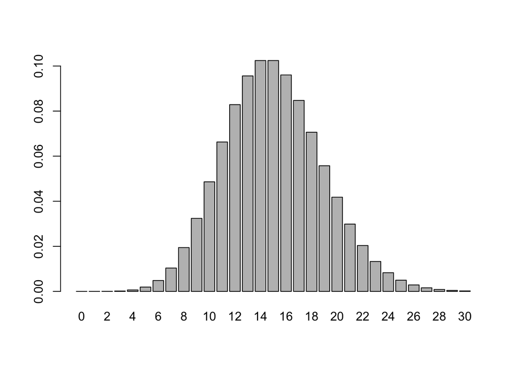

```r
x <- 0:30
l = 15
probset <- dpois(x = x, lambda = l)
barplot(probset, names.arg = x)
```

### 1e. Simulate 104 results from this distribution (i.e., 2 years of Saturday monitoring sessions).Plot the simulated results using hist() and use xlim() to set the horizontal limits to be from 0 to 30. How does your histogram compare to the shape of the probability mass function you plotted above?

```r
sample(x, 104,replace = TRUE)
```

```
##   [1]  0 26 16 19 17  4 26 11 17 13  3 29 10  5 20 14  9 24 26 17 15 27  2
##  [24]  7 14  7 22  9 17 22 21  8 10  4 12  8 23 22  0 19 11 22 15 12  6 13
##  [47]  5 29 17 22  3  3  5 30 29  4 14  8 11 16 19 27  8  2 10  6 25 24 30
##  [70] 14  1  2  3 23 16 28 25 22  9 16 16 23 13 25 22 16  1  6 12 13 18 16
##  [93]  1  9 22  9  4 14 13 10 12  6  3  0
```

### 1f. Plot the simulated results using hist() and use xlim() to set the horizontal limits to be from 0 to 30. How does your histogram compare to the shape of the probability mass function you plotted above?

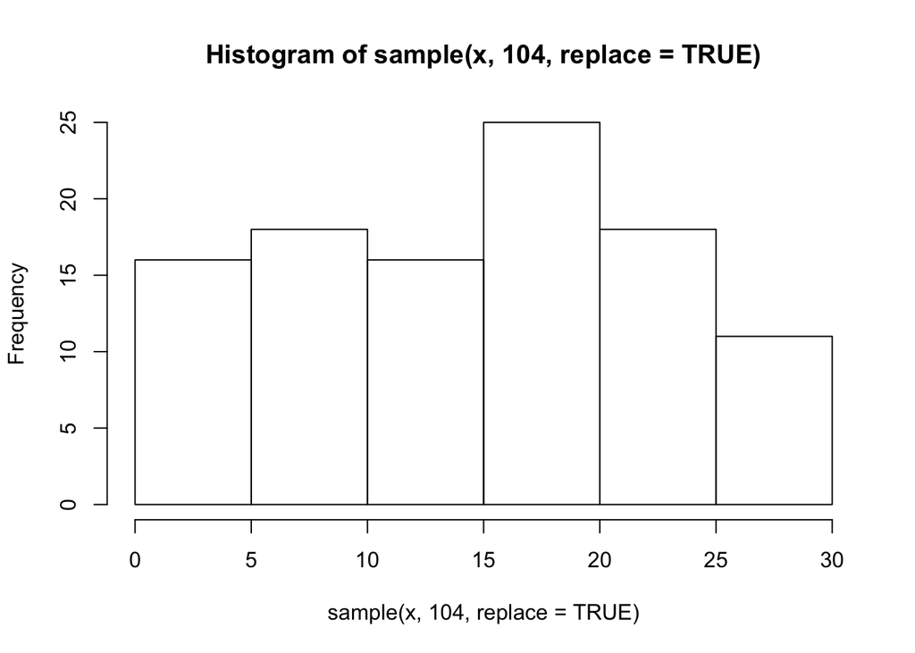

```r
hist(sample(x, 104,replace = TRUE), xlim=c(0,30))
```

# Challenge 11.2

```r
f<-"~/Desktop/zombies.csv"
d <- read.table(f, header = TRUE, sep = ",", stringsAsFactors = FALSE)
head(d)
```

```
##   id first_name last_name gender   height   weight zombies_killed
## 1  1      Sarah    Little Female 62.88951 132.0872              2
## 2  2       Mark    Duncan   Male 67.80277 146.3753              5
## 3  3    Brandon     Perez   Male 72.12908 152.9370              1
## 4  4      Roger   Coleman   Male 66.78484 129.7418              5
## 5  5      Tammy    Powell Female 64.71832 132.4265              4
## 6  6    Anthony     Green   Male 71.24326 152.5246              1
##   years_of_education                           major      age
## 1                  1                medicine/nursing 17.64275
## 2                  3 criminal justice administration 22.58951
## 3                  1                       education 21.91276
## 4                  6                  energy studies 18.19058
## 5                  3                       logistics 21.10399
## 6                  4                  energy studies 21.48355
```

### 2a) Calculate the population mean and standard deviation for each quantitative random variable (height, weight, age, number of zombies killed, and years of education).

```r
summary(d)
```

```
##        id          first_name         last_name            gender
##  Min.   :   1.0   Length:1000        Length:1000        Length:1000
##  1st Qu.: 250.8   Class :character   Class :character   Class :character
##  Median : 500.5   Mode  :character   Mode  :character   Mode  :character
##  Mean   : 500.5
##  3rd Qu.: 750.2
##  Max.   :1000.0
##      height          weight       zombies_killed   years_of_education
##  Min.   :54.15   Min.   : 90.29   Min.   : 0.000   Min.   :0.000
##  1st Qu.:64.68   1st Qu.:131.81   1st Qu.: 2.000   1st Qu.:2.000
##  Median :67.50   Median :142.89   Median : 3.000   Median :3.000
##  Mean   :67.63   Mean   :143.91   Mean   : 2.992   Mean   :2.996
##  3rd Qu.:70.38   3rd Qu.:156.28   3rd Qu.: 4.000   3rd Qu.:4.000
##  Max.   :80.53   Max.   :210.79   Max.   :11.000   Max.   :8.000
##     major                age
##  Length:1000        Min.   :10.66
##  Class :character   1st Qu.:18.07
##  Mode  :character   Median :19.90
##                     Mean   :20.05
##                     3rd Qu.:21.94
##                     Max.   :29.59
```

```r
names(d)
```

```
##  [1] "id"                 "first_name"         "last_name"
##  [4] "gender"             "height"             "weight"
##  [7] "zombies_killed"     "years_of_education" "major"
## [10] "age"
```

```r
mean(d$height, na.rm=TRUE)
```

```
## [1] 67.6301
```

```r
mean(d$age, na.rm=TRUE)
```

```
## [1] 20.04696
```

```r
mean(d$zombies_killed, na.rm=TRUE)
```

```
## [1] 2.992
```

```r
mean(d$years_of_education, na.rm=TRUE)
```

```
## [1] 2.996
```

```r
sqrt(sum((d$height-mean(d$height))^2)/length(d$height))
```

```
## [1] 4.30797
```

```r
sqrt(sum((d$weight-mean(d$weight))^2)/length(d$weight))
```

```
## [1] 18.39186
```

```r
sqrt(sum((d$age-mean(d$age))^2)/length(d$age))
```

```
## [1] 2.963583
```

```r
sqrt(sum((d$zombies_killed-mean(d$zombies_killed))^2)/length(d$zombies_killed))
```

```
## [1] 1.747551
```

```r
sqrt(sum((d$years_of_education-mean(d$years_of_education))^2)/length(d$years_of_education))
```

```
## [1] 1.675704
```

### 2b)Use {ggplot} and make boxplots of each of these variable by gender.

```r
library(ggplot2)
```

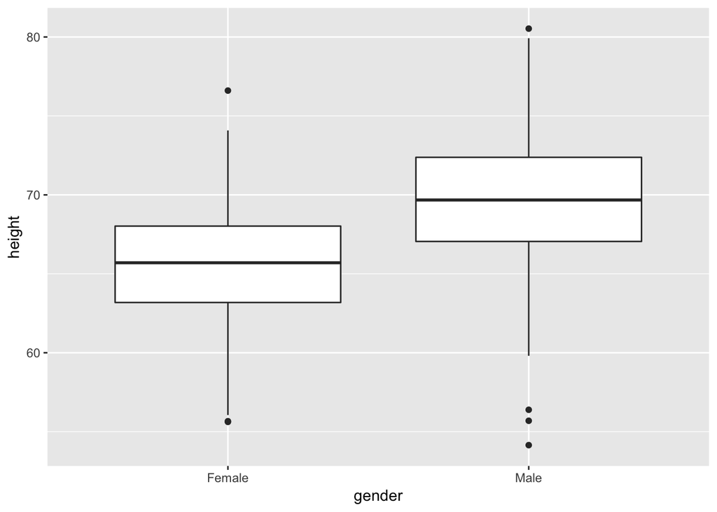

```r
ggplot(d, aes(x=gender, y=height)) + geom_boxplot()
```

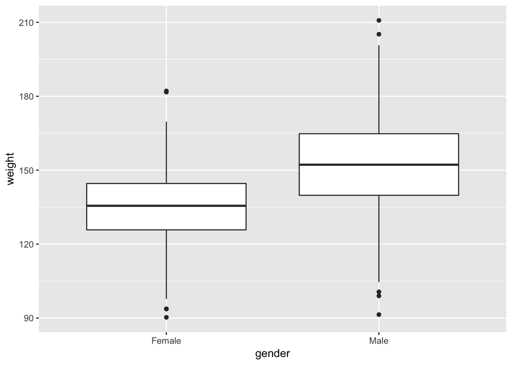

```r
ggplot(d, aes(x=gender, y=weight)) + geom_boxplot()
```

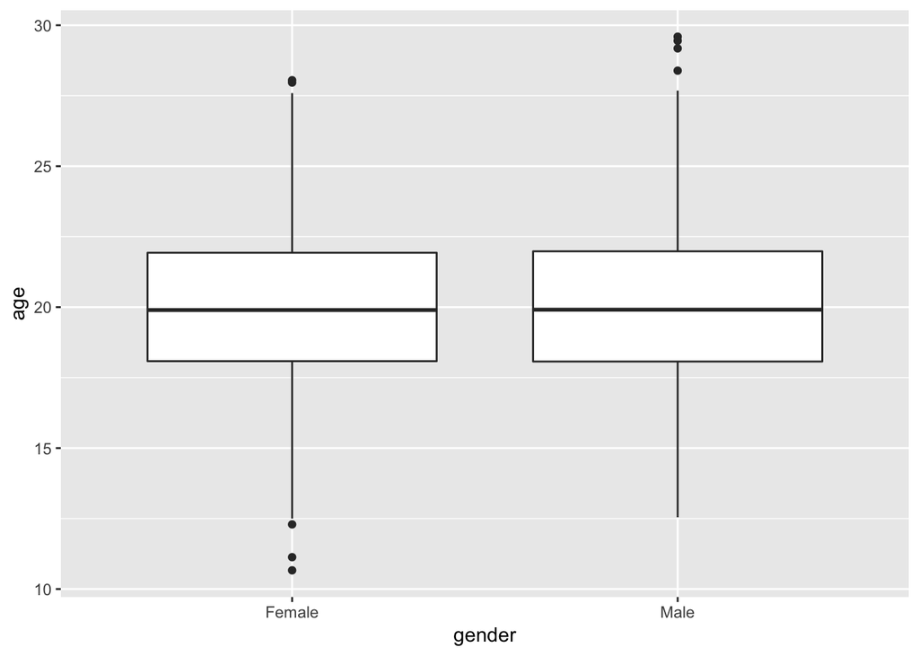

```r
ggplot(d, aes(x=gender, y=age)) + geom_boxplot()
```

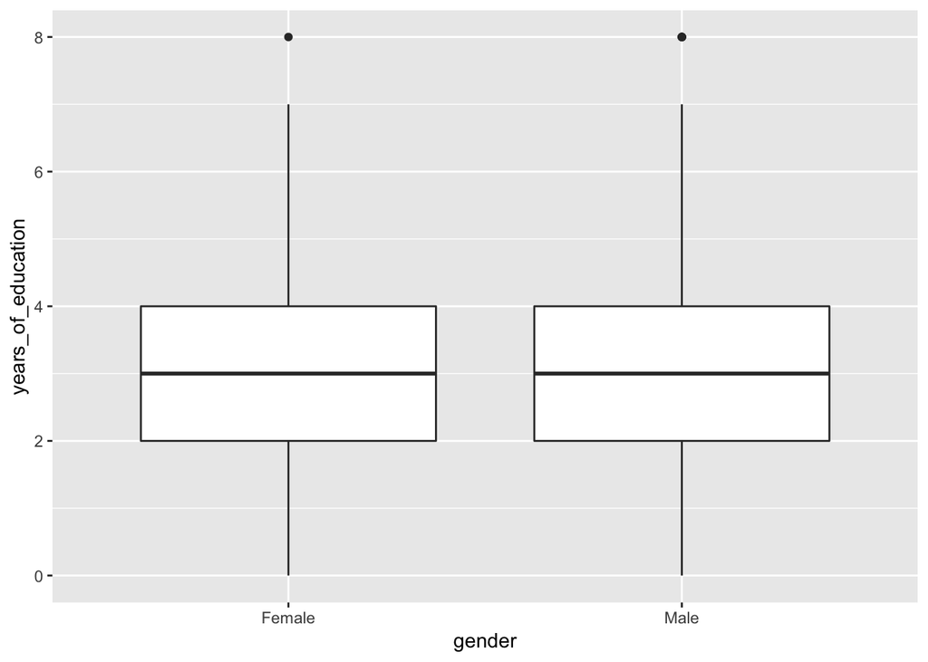

```r
ggplot(d, aes(x=gender, y=years_of_education)) + geom_boxplot()
```

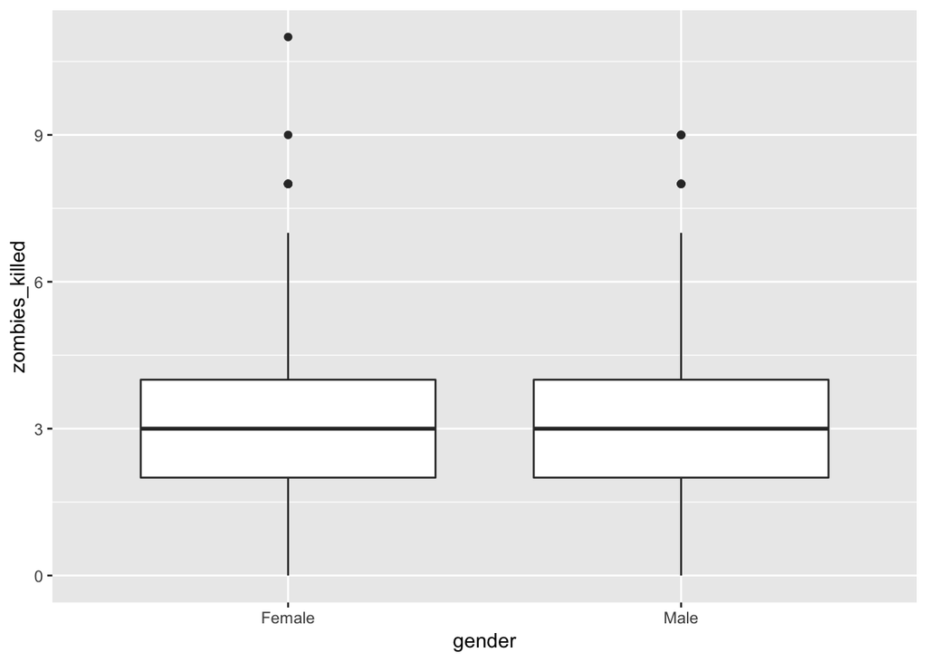

```r
ggplot(d, aes(x=gender, y=zombies_killed)) + geom_boxplot()
```

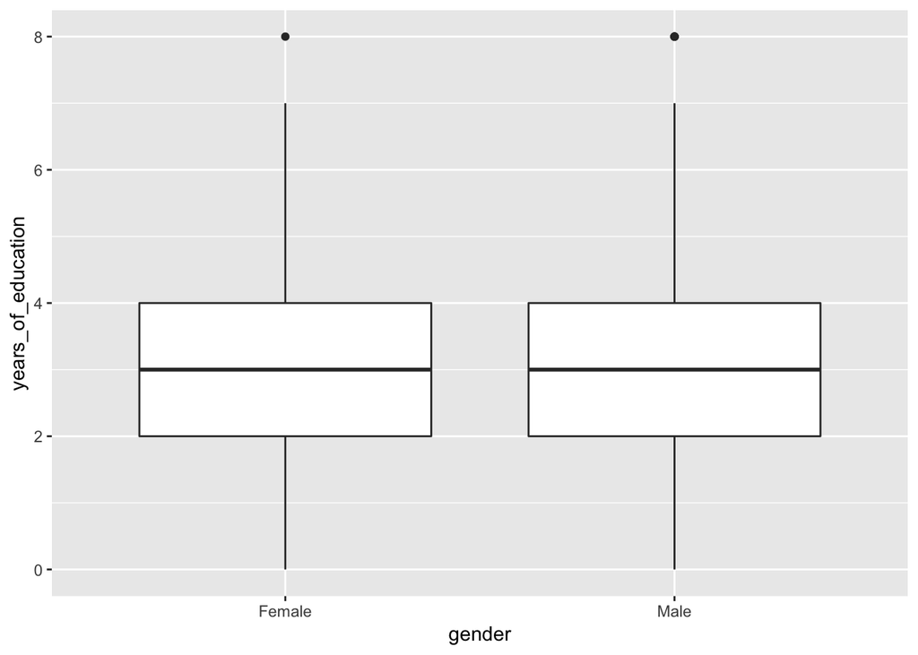

```r
ggplot(d, aes(x=gender, y=years_of_education)) + geom_boxplot()
```

### 2c)Use {ggplot} and make scatterplots of height and weight in relation to age. Do these variables seem to be related? In what way?

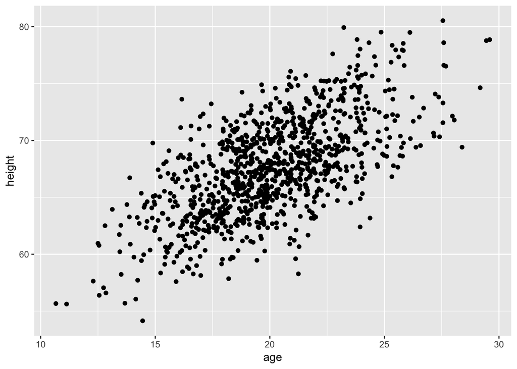

```r
ggplot(data = d, aes(x = age, y=height)) + geom_point()
```

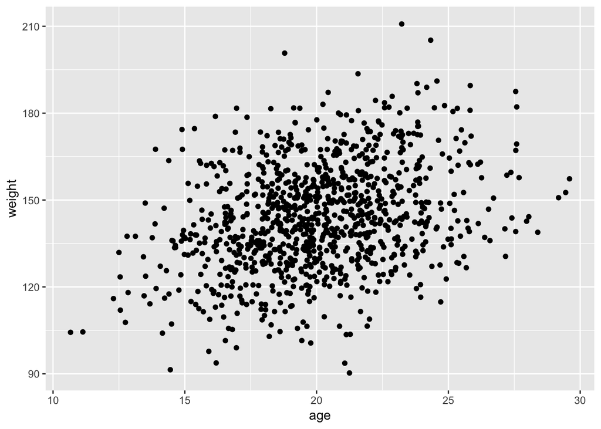

```r
ggplot(data = d, aes(x = age, y=weight)) + geom_point()
```

#### Height and weight both seem to have a positive correlation with age, as age increases so does height and weight. However, there appears to be a stronger relationship between height and age

### 2d) Using histograms and Q-Q plots, check whether the quantitative variables seem to be drawn from a normal distribution. Which seem to be and which do not?

### Height

```r
summary(d$height)
```

```
##    Min. 1st Qu.  Median    Mean 3rd Qu.    Max.
##   54.15   64.68   67.50   67.63   70.38   80.53
```

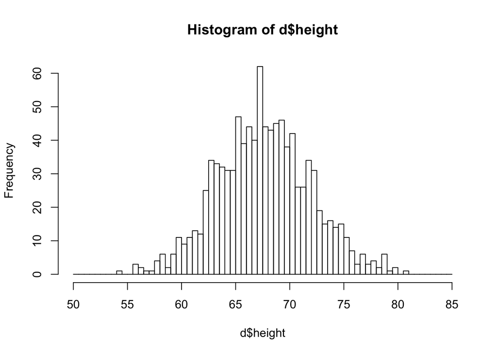

```r
hist(d$height, breaks = seq(from=50, to=85, by=.5))
```

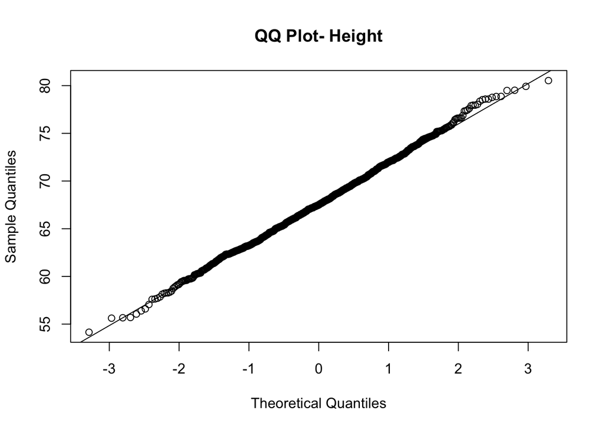

```r
qqnorm(d$height, main = "QQ Plot- Height")
qqline(d$height)
```

### Weight

```r
summary(d$weight)
```

```
##    Min. 1st Qu.  Median    Mean 3rd Qu.    Max.
##   90.29  131.81  142.89  143.91  156.28  210.79
```

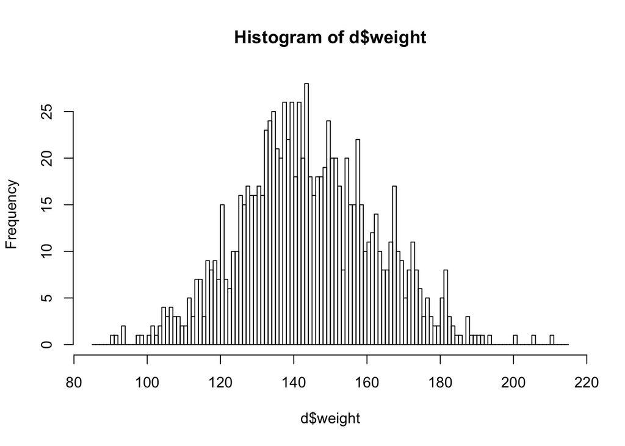

```r
hist(d$weight, breaks = seq(from=85, to=215, by=1))
```

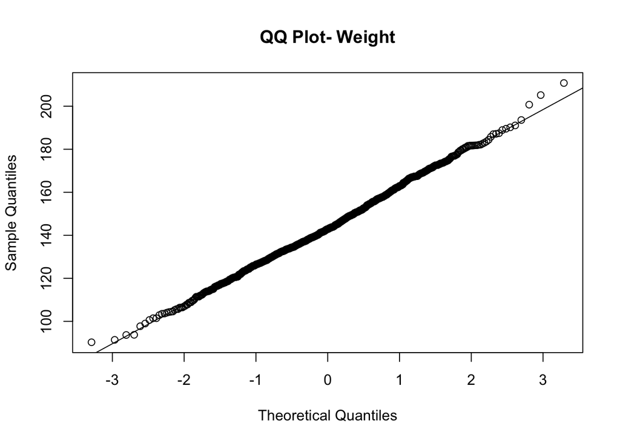

```r
qqnorm(d$weight, main = "QQ Plot- Weight")
qqline(d$weight)
```

### Age

```r
summary(d$age)
```

```
##    Min. 1st Qu.  Median    Mean 3rd Qu.    Max.
##   10.66   18.07   19.90   20.05   21.94   29.59
```

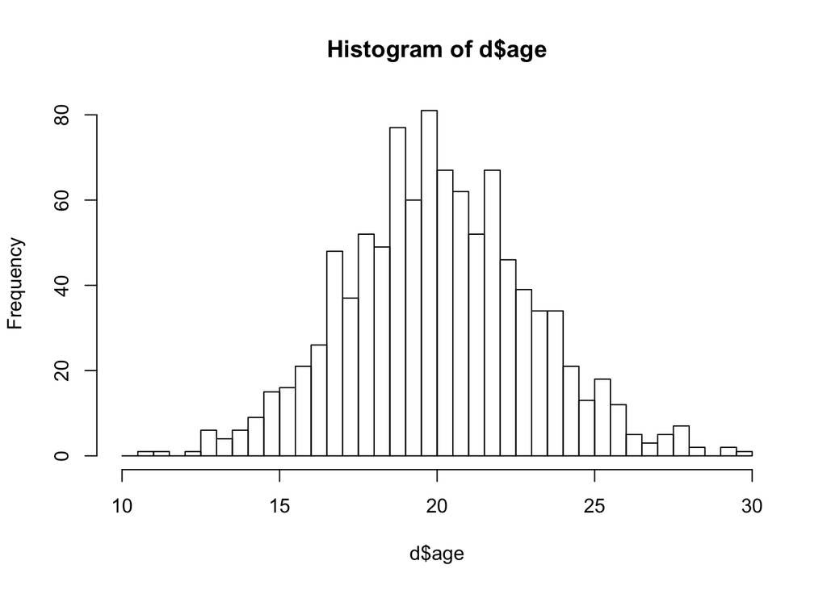

```r
hist(d$age, breaks = seq(from=10, to=30, by=.5))
```

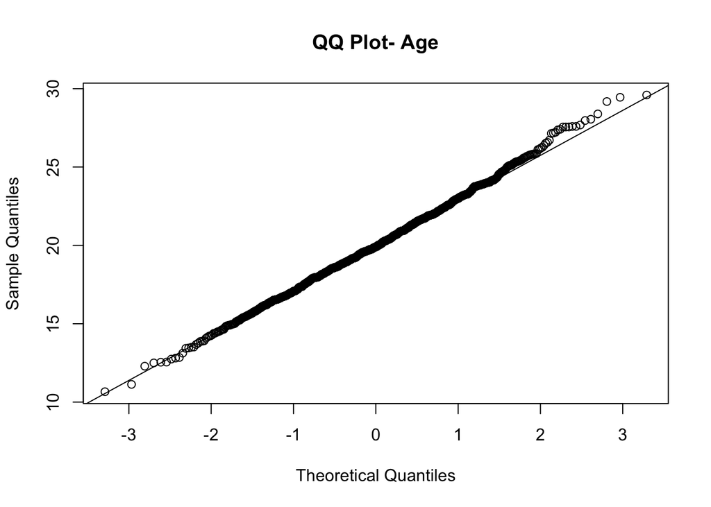

```r
qqnorm(d$age, main = "QQ Plot- Age")
qqline(d$age)
```

### Years of Education

```r
summary(d$years_of_education)
```

```
##    Min. 1st Qu.  Median    Mean 3rd Qu.    Max.
##   0.000   2.000   3.000   2.996   4.000   8.000
```

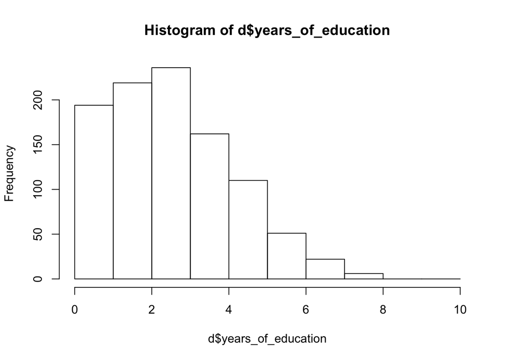

```r
hist(d$years_of_education, breaks = seq(from=0, to=10, by=1))
```

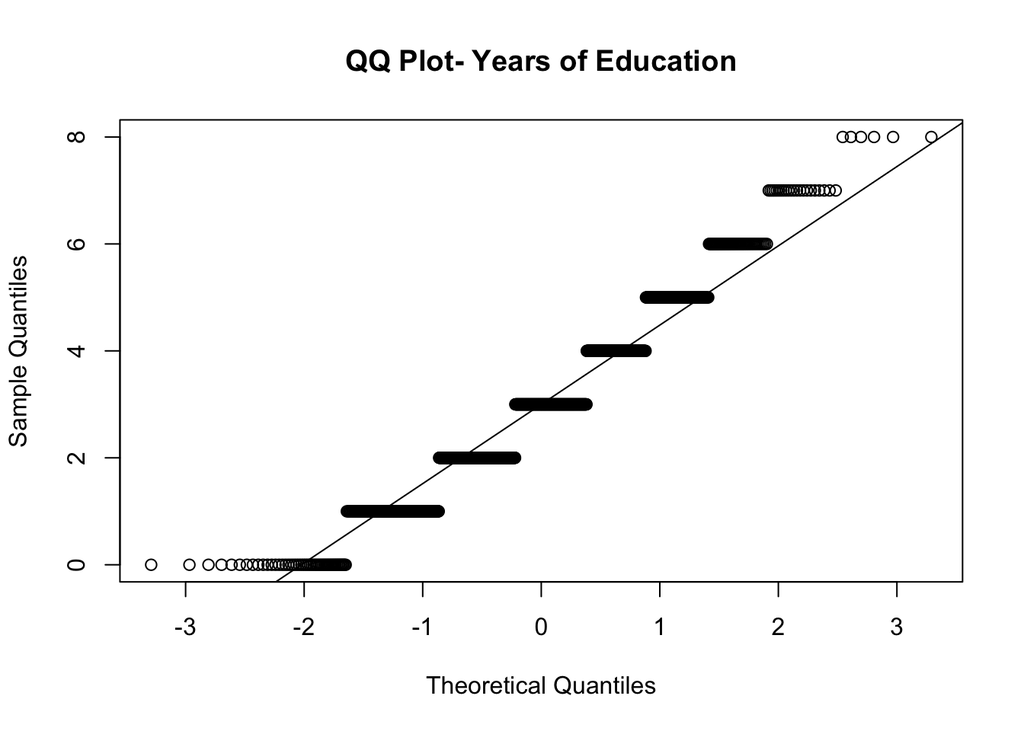

```r
qqnorm(d$years_of_education, main = "QQ Plot- Years of Education")
qqline(d$years_of_education)
```

### Zombies Killed

[output not shown]

#### Height, weight, and age seem to be drawn from a normal distribution, whereas years of education and zombies killed do not.

### 2e) Now use the sample() function to sample ONE subset of 30 zombies (without replacement) from this population and calculate the mean and sample standard deviation for each variable. Also estimate the standard error for each variable and construct the 95% confidence interval for each mean. Note that for the variables that are not drawn from the normal distribution, you will need to base your estimate of the CIs on some different distribution!

```r
Z<- d[sample(nrow(d),30),]
Z
```

```
##      id first_name last_name gender   height   weight zombies_killed
## 842 842      Marie  Marshall Female 57.71565 116.1210              6
## 955 955     Daniel    George   Male 67.06186 151.7098              3
## 79   79    Phillip      King   Male 70.35090 158.2718              4
## 470 470     Edward  Gonzales   Male 67.72148 160.3177              0
## 396 396     Johnny    Murphy   Male 72.84810 147.5562              4
## 621 621      James    Bowman   Male 69.28285 154.1875              4
## 691 691      Nancy   Wallace Female 67.38948 149.4575              5
## 916 916     Arthur     Grant   Male 67.77419 137.1519              4
## 747 747    Richard Patterson   Male 71.72428 158.3285              5
## 568 568      Susan    Weaver Female 71.51768 168.6501              5
## 352 352      Jason       Kim   Male 73.81395 171.5612              2
## 177 177       Juan    Barnes   Male 62.33876 133.5535              3
## 455 455      Keith     Burns   Male 71.72562 157.6048              3
## 680 680    Russell     Henry   Male 68.15269 155.5859              3
```

[output cut: 47 more lines]

### Height

```r
mean(Z$height)
```

```
## [1] 67.80049
```

```r
sd(Z$height)
```

```
## [1] 4.214528
```

```r
se(Z$height)
```

```
## [1] 0.769464
```

```r
qnorm(0.025, mean(Z$height), sd(Z$height))
```

```
## [1] 59.54016
```

```r
qnorm(0.975,mean(Z$height),sd(Z$height))
```

```
## [1] 76.06081
```

### Weight

```r
mean(Z$weight)
```

```
## [1] 145.5408
```

```r
sd(Z$weight)
```

```
## [1] 17.84653
```

```r
se(Z$weight)
```

```
## [1] 3.258315
```

```r
qnorm(0.025, mean(Z$weight), sd(Z$weight))
```

```
## [1] 110.5622
```

```r
qnorm(0.975,mean(Z$weight),sd(Z$weight))
```

```
## [1] 180.5193
```

### Zombies Killed

```r
mean(Z$zombies_killed)
```

```
## [1] 3.333333
```

```r
sd(Z$zombies_killed)
```

```
## [1] 1.582955
```

```r
se(Z$zombies_killed)
```

```
## [1] 0.2890068
```

```r
quantile(Z$zombies_killed, c(0.025, 0.975))
```

```
##  2.5% 97.5%
##     0     6
```

```r
summary(Z$zombies_killed)
```

```
##    Min. 1st Qu.  Median    Mean 3rd Qu.    Max.
##   0.000   2.250   3.500   3.333   4.000   6.000
```

### Years of Education

```r
mean(Z$years_of_education)
```

```
## [1] 2.6
```

```r
sd(Z$years_of_education)
```

```
## [1] 1.610312
```

```r
se(Z$years_of_education)
```

```
## [1] 0.2940013
```

```r
quantile(Z$years_of_education, c(0.025, 0.975))
```

```
##  2.5% 97.5%
## 0.725 5.550
```

```r
summary(Z$years_of_education)
```

```
##    Min. 1st Qu.  Median    Mean 3rd Qu.    Max.
##     0.0     1.0     3.0     2.6     4.0     7.0
```

### Age

```r
mean(Z$age)
```

```
## [1] 20.01149
```

```r
sd(Z$age)
```

```
## [1] 2.662888
```

```r
se(Z$age)
```

```
## [1] 0.4861747
```

```r
qnorm(0.025, mean(Z$age), sd(Z$age))
```

```
## [1] 14.79233
```

```r
qnorm(0.975,mean(Z$age),sd(Z$age))
```

```
## [1] 25.23066
```

### 2f) Now draw 99 more random samples of 30 zombie apocalypse survivors out and calculate the mean for each of the these samples. Together with the first sample you drew out, you now have a set of 100 means for each variable (each based on 30 observations), which constitutes a sampling distribution for each variable. What are the means and standard deviations of the sampling distribution for each variable? How do the standard deviations compare to the standard errors estimated in [2.e.]? What do these sampling distributions look like? Are they normally distributed? What about for those variables that you concluded were not originally drawn from a normal distribution?

```r
k <- 99
n <- 30
s <- NULL
for (i in 1:k) {
  s[[i]] <- d[sample(nrow(d),30),]
}
```

### Height

```r
Mean_Height<-NULL
for (i in 1:k) {
  Mean_Height[i]<- mean(s[[i]]$height)
}
Mean_Height
```

```
##  [1] 67.01922 68.02707 67.29989 66.75851 66.98278 68.00929 67.59515
##  [8] 68.02751 67.40125 66.82962 68.22892 67.42929 65.39644 68.33615
## [15] 68.26110 68.54021 66.93118 68.24165 66.99008 67.90563 68.95910
## [22] 68.38972 67.65150 68.15873 67.96332 67.43397 68.55585 67.27801
## [29] 69.04959 67.79784 66.11054 67.91856 68.41776 67.77864 69.10110
## [36] 66.83107 66.19418 67.53845 67.75822 66.84050 67.98371 67.26910
## [43] 68.89566 66.22863 68.89849 67.15896 67.47593 67.25106 67.64029
## [50] 68.34408 66.28595 67.98526 67.97277 67.52018 68.95914 68.95020
## [57] 68.46295 68.56647 67.06792 67.74902 69.01128 68.45780 67.69789
## [64] 68.01256 67.24636 68.29388 68.10094 67.59794 67.28073 66.64742
## [71] 68.23521 68.36773 67.21257 66.97631 68.00262 67.28709 67.40556
## [78] 67.36233 66.65102 67.84305 67.64825 68.12218 66.99056 68.68828
## [85] 66.11415 68.47263 67.83063 68.69565 67.36708 67.94826 67.43053
## [92] 67.49206 68.51002 67.45213 66.96015 68.20146 67.84490 67.45786
## [99] 67.40072
```

### Weight

```r
Mean_Weight<-NULL
for (i in 1:k) {
  Mean_Weight[i]<- mean(s[[i]]$weight)
}
Mean_Weight
```

```
##  [1] 143.3549 150.4801 142.5629 140.8060 143.8117 146.4457 143.4536
##  [8] 142.9921 141.0085 139.8300 148.3713 140.2359 139.6611 145.3334
## [15] 144.8408 146.0057 141.7777 148.2605 139.6371 144.1375 147.3698
## [22] 145.8082 146.4331 145.9757 143.7011 143.5573 145.2699 139.1240
## [29] 148.7361 141.6259 138.9547 143.6504 146.9844 143.7084 147.8019
## [36] 142.6296 137.4565 143.6618 142.8641 139.6809 144.2750 142.6214
## [43] 149.5873 139.5917 147.2387 143.2612 143.4438 141.1635 143.2180
## [50] 148.0326 139.4220 143.0953 145.3015 142.4536 148.1583 147.6382
## [57] 150.1883 148.1406 142.6555 148.0212 148.4507 146.7193 144.5766
## [64] 141.8908 141.6979 145.4846 148.0740 145.0278 140.3938 137.5400
## [71] 142.9325 148.5086 143.4488 140.2955 146.0737 141.7047 142.5985
## [78] 146.3309 138.0031 146.8478 143.2432 149.6107 144.6227 146.2022
## [85] 137.1727 147.9064 145.8554 148.9646 145.5509 142.1022 143.9084
## [92] 142.1204 147.5695 142.7123 141.8809 149.3667 142.6143 144.6862
## [99] 141.9192
```

### Age

```r
Mean_Age<-NULL
for (i in 1:k) {
  Mean_Age[i]<- mean(s[[i]]$age)
}
Mean_Age
```

```
##  [1] 19.74871 19.79833 20.29961 19.48840 19.34146 20.52582 19.58058
##  [8] 20.42392 20.41302 20.23024 21.01230 20.14994 19.39271 20.48057
## [15] 20.61012 20.70725 19.83400 20.12826 20.14795 20.57583 20.80496
## [22] 20.98249 20.71132 20.88012 20.55691 20.64904 20.42224 20.62818
## [29] 20.51058 20.24979 19.81978 20.37447 20.10078 20.03531 20.78731
## [36] 19.77355 19.73767 19.39744 20.27599 19.92733 20.45753 20.82500
## [43] 20.50391 18.81068 20.81810 19.76548 19.56017 20.15003 20.13449
## [50] 19.89883 19.95614 20.51230 20.44730 20.10560 20.66320 20.94974
## [57] 19.95148 19.93125 19.87283 19.88015 21.42800 19.99805 20.52156
## [64] 20.87114 19.95635 20.71544 19.61259 19.56453 20.50515 19.78299
## [71] 20.78894 20.35937 19.01493 20.97517 19.70738 19.87624 19.61894
## [78] 19.93627 19.64625 20.49028 20.08111 20.07400 19.38832 20.53312
## [85] 19.46236 20.85574 20.91991 20.17514 19.44599 20.37937 19.24379
## [92] 20.93235 20.33096 20.81168 20.02023 20.23366 21.09172 20.33887
## [99] 19.99884
```

### Zombies Killed

```r
Mean_Zombies_Killed<-NULL
for (i in 1:k) {
  Mean_Zombies_Killed[i]<- mean(s[[i]]$zombies_killed)
}
Mean_Zombies_Killed
```

```
##  [1] 3.066667 3.133333 3.100000 2.900000 2.833333 2.766667 2.866667
##  [8] 3.100000 2.866667 2.800000 2.366667 3.133333 2.966667 3.000000
## [15] 3.300000 2.766667 3.100000 3.166667 2.866667 2.800000 3.333333
## [22] 2.666667 3.200000 2.900000 2.900000 3.166667 2.933333 3.033333
## [29] 2.833333 3.100000 2.900000 2.866667 3.166667 3.400000 2.733333
## [36] 2.900000 2.633333 2.700000 2.766667 2.733333 3.233333 2.833333
## [43] 2.500000 2.733333 3.066667 3.266667 2.400000 2.933333 2.833333
## [50] 3.533333 3.166667 3.200000 2.800000 2.766667 3.033333 3.200000
## [57] 2.933333 3.333333 2.466667 2.933333 3.166667 3.233333 2.633333
## [64] 3.300000 3.200000 2.066667 3.066667 3.966667 3.733333 3.133333
## [71] 2.966667 3.033333 2.466667 2.666667 2.366667 2.566667 2.733333
## [78] 3.033333 2.866667 2.566667 3.400000 3.366667 2.633333 3.233333
## [85] 2.800000 3.133333 2.700000 3.133333 3.366667 3.066667 2.566667
## [92] 2.733333 2.866667 3.100000 3.366667 3.266667 2.933333 3.200000
## [99] 2.966667
```

### Years of Education

```r
Mean_Years_Education<-NULL
for (i in 1:k) {
  Mean_Years_Education[i]<- mean(s[[i]]$years_of_education)
}
Mean_Years_Education
```

```
##  [1] 3.300000 3.233333 2.633333 2.333333 2.600000 2.866667 3.233333
##  [8] 3.266667 2.800000 2.600000 2.700000 3.066667 2.733333 2.766667
## [15] 3.333333 3.100000 3.166667 3.166667 3.233333 2.866667 3.066667
## [22] 2.700000 3.000000 3.133333 3.033333 2.966667 2.766667 3.100000
## [29] 2.866667 2.533333 2.666667 3.100000 2.766667 2.600000 2.933333
## [36] 3.000000 3.200000 3.166667 3.100000 2.666667 2.866667 2.766667
## [43] 3.200000 3.466667 2.966667 2.666667 3.133333 3.166667 2.733333
## [50] 2.966667 2.866667 2.866667 2.900000 2.966667 3.200000 2.633333
## [57] 3.700000 2.700000 3.600000 3.066667 2.833333 2.900000 3.666667
## [64] 2.700000 3.366667 2.833333 2.833333 2.533333 3.166667 2.366667
## [71] 3.200000 2.900000 3.333333 2.500000 3.033333 3.400000 2.533333
## [78] 3.000000 2.533333 3.100000 2.866667 3.266667 2.533333 2.800000
## [85] 3.066667 2.733333 2.900000 3.166667 2.400000 2.600000 2.533333
## [92] 2.733333 3.266667 3.066667 2.933333 2.400000 3.333333 3.100000
## [99] 3.866667
```

```r
zzsamp<- as.data.frame(zzsamp)
zzsamp
```

```
##      Mean_Height Mean_Weight Mean_Age Mean_Zombies_Killed
## X       67.01922    143.3549 19.74871            3.066667
## X.1     68.02707    150.4801 19.79833            3.133333
## X.2     67.29989    142.5629 20.29961            3.100000
## X.3     66.75851    140.8060 19.48840            2.900000
## X.4     66.98278    143.8117 19.34146            2.833333
## X.5     68.00929    146.4457 20.52582            2.766667
## X.6     67.59515    143.4536 19.58058            2.866667
## X.7     68.02751    142.9921 20.42392            3.100000
## X.8     67.40125    141.0085 20.41302            2.866667
## X.9     66.82962    139.8300 20.23024            2.800000
## X.10    68.22892    148.3713 21.01230            2.366667
## X.11    67.42929    140.2359 20.14994            3.133333
## X.12    65.39644    139.6611 19.39271            2.966667
## X.13    68.33615    145.3334 20.48057            3.000000
## X.14    68.26110    144.8408 20.61012            3.300000
## X.15    68.54021    146.0057 20.70725            2.766667
## X.16    66.93118    141.7777 19.83400            3.100000
## X.17    68.24165    148.2605 20.12826            3.166667
## X.18    66.99008    139.6371 20.14795            2.866667
## X.19    67.90563    144.1375 20.57583            2.800000
## X.20    68.95910    147.3698 20.80496            3.333333
## X.21    68.38972    145.8082 20.98249            2.666667
## X.22    67.65150    146.4331 20.71132            3.200000
## X.23    68.15873    145.9757 20.88012            2.900000
## X.24    67.96332    143.7011 20.55691            2.900000
## X.25    67.43397    143.5573 20.64904            3.166667
## X.26    68.55585    145.2699 20.42224            2.933333
## X.27    67.27801    139.1240 20.62818            3.033333
## X.28    69.04959    148.7361 20.51058            2.833333
## X.29    67.79784    141.6259 20.24979            3.100000
## X.30    66.11054    138.9547 19.81978            2.900000
## X.31    67.91856    143.6504 20.37447            2.866667
## X.32    68.41776    146.9844 20.10078            3.166667
## X.33    67.77864    143.7084 20.03531            3.400000
## X.34    69.10110    147.8019 20.78731            2.733333
## X.35    66.83107    142.6296 19.77355            2.900000
## X.36    66.19418    137.4565 19.73767            2.633333
## X.37    67.53845    143.6618 19.39744            2.700000
## X.38    67.75822    142.8641 20.27599            2.766667
```

[output cut: 147 more lines]

```
## X.85             2.733333
## X.86             2.900000
## X.87             3.166667
## X.88             2.400000
## X.89             2.600000
## X.90             2.533333
## X.91             2.733333
## X.92             3.266667
## X.93             3.066667
## X.94             2.933333
## X.95             2.400000
## X.96             3.333333
## X.97             3.100000
## X.98             3.866667
## res1             2.600000
```

### Height

```r
mean(zzsamp$Mean_Height)
```

```
## [1] 67.70722
```

```r
sd(zzsamp$Mean_Height)
```

```
## [1] 0.7404978
```

```r
se(Z$height)
```

```
## [1] 0.769464
```

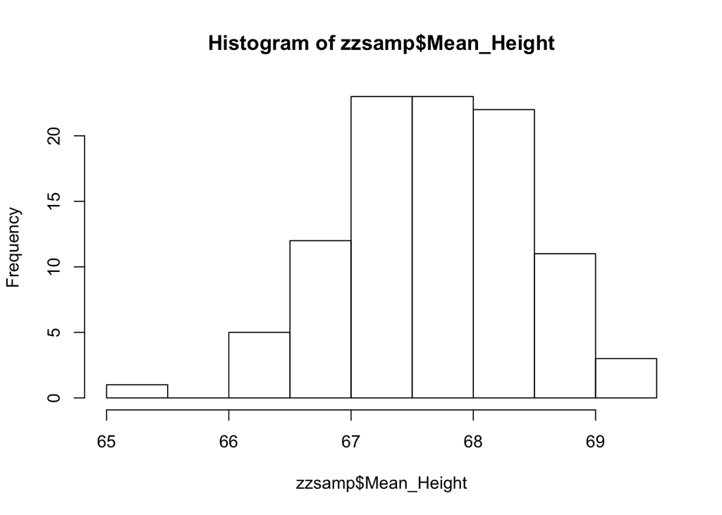

```r
hist(zzsamp$Mean_Height)
```

### Weight

```r
mean(zzsamp$Mean_Weight)
```

```
## [1] 144.1566
```

```r
sd(zzsamp$Mean_Weight)
```

```
## [1] 3.177112
```

```r
se(Z$weight)
```

```
## [1] 3.258315
```

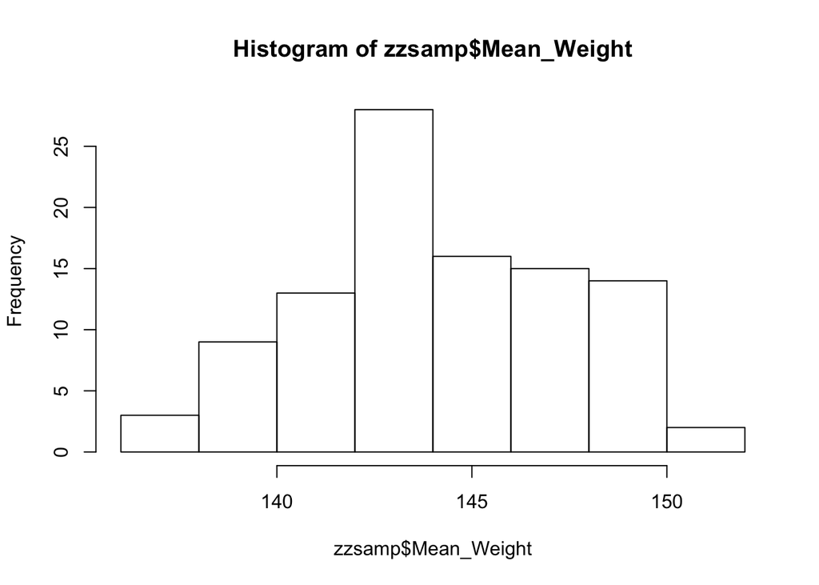

```r
hist(zzsamp$Mean_Weight)
```

### Age

```r
mean(zzsamp$Mean_Age)
```

```
## [1] 20.20407
```

```r
sd(zzsamp$Mean_Age)
```

```
## [1] 0.5112309
```

```r
se(Z$age)
```

```
## [1] 0.4861747
```

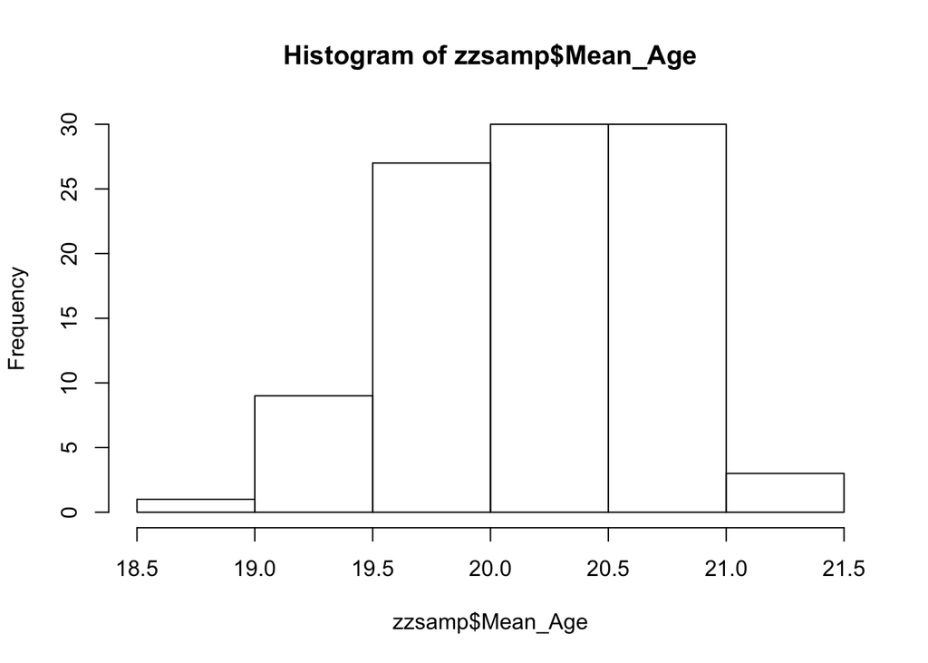

```r
hist(zzsamp$Mean_Age)
```

### Zombies Killed

```r
mean(zzsamp$Mean_Zombies_Killed)
```

```
## [1] 2.968667
```

```r
sd(zzsamp$Mean_Zombies_Killed)
```

```
## [1] 0.3006473
```

```r
se(Z$zombies_killed)
```

```
## [1] 0.2890068
```

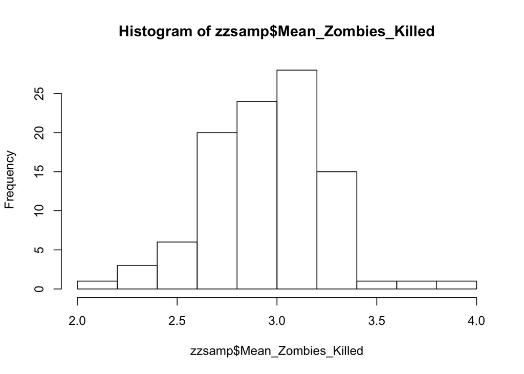

```r
hist(zzsamp$Mean_Zombies_Killed)
```

### Years of Education

```r
mean(zzsamp$Mean_Years_Education)
```

```
## [1] 2.947
```

```r
sd(zzsamp$Mean_Years_Education)
```

```
## [1] 0.3056922
```

```r
se(Z$years_of_education)
```

```
## [1] 0.2940013
```

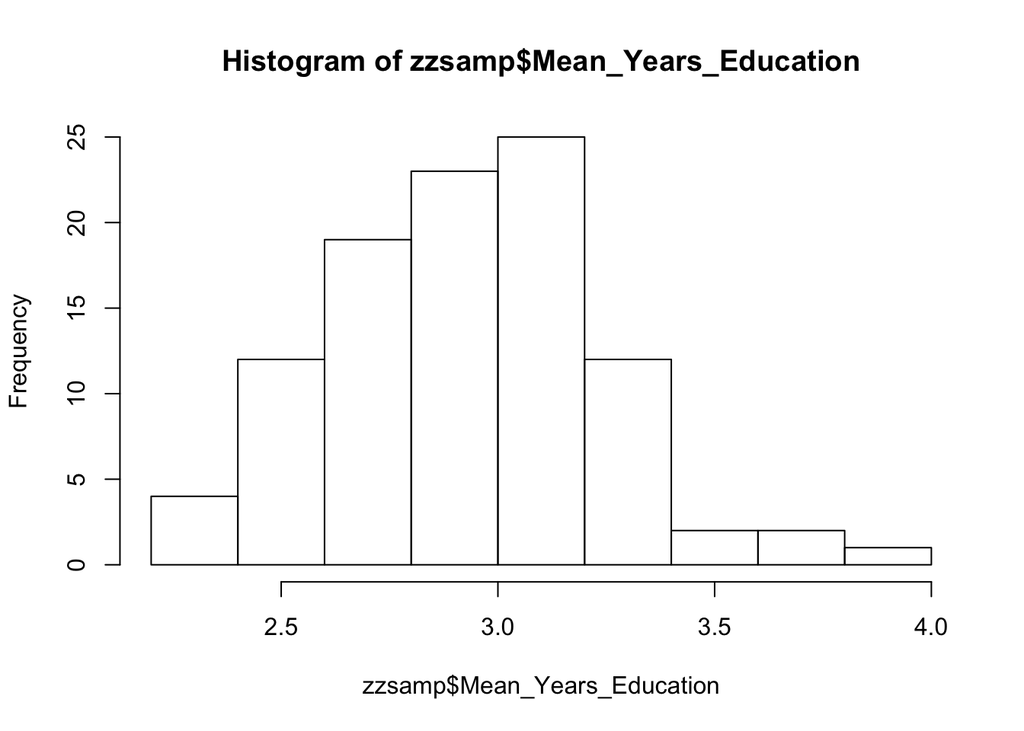

```r
hist(zzsamp$Mean_Years_Education)
```

#### The variables that didn’t appear to follow a normal distribution, now look more like one.